# DIY Classifier

# Introduction

As an additional bonus to the AllSorts Classifier I wish to create a little notebook to illustrate how one might make their own classifier.

*Why create your own classifier if AllSorts is so good?*

- All classifiers (AllSorts included) are only as good as the data they train on and their underlying compositions and biases.
- There are more sub-classes in *Other* which one may wish to train for in order to distinguish.
- Being able to create a classifier specific for samples extracted with your lab/university/hospitals technical biases should be more accurate than a general classifier.
- Its fun!

*What do I need to create my own classifier?*

- Lots of data with truth information, that is a label which indicates which class the samples should actually be defined as.
- A good composition of samples: A similar number of samples for each category which you desire to classify (such that you have a representative number of samples from which to construct the classifier from)
- Someone happy to read an implement R code and whom understands the data and its biases.

# Start Point: Check out your data

The beginnings of all data analysis journeys commence with looking at your data, understanding its strength and weaknesses and making sense of it.

Read in your data.

**Caveat:** For this notebook we will use a toy dataset of 195 samples simulated using Splatter (https://github.com/Oshlack/splatter) where we have estimated the parameters of simulation from real data.

The simulated dataset can be found: https://github.com/Quarkins/Bioinformatics-Tidbits/tree/master/data

```r
library(ggplot2)
library(edgeR)
library(randomForest)
library(RColorBrewer)
library(gplots)
```

```r
#Prepare counts data
counts <- read.table(file="splat_counts.txt",sep="\t",stringsAsFactors=FALSE,row.names=1,header=TRUE)

#Get raw counts matrix
rcounts <- counts[,1:195]

#Extract gene lengths
llength <- counts$Length
```

What we also need is the sample information, including what the true class for each sample is:

```r
targets <- read.table(file="splat_targets.txt",sep="\t",stringsAsFactors=FALSE,row.names=1,header=TRUE)
```

Finally lets make a DGElist object (edgeR’s preferred object type) which we will then filter and normalise. We want to filter out some of the chaff from the data, that is to say genes which don’t have many counts in any of the samples as they are probably suprious and won’t contain much of the interesting biology but just add noise to the data.

```r
#Only keep if the counts per million are greater than 1 in 30 or more samples
y <- DGEList(counts=rcounts, genes=row.names(rcounts))
keep <- rowSums(cpm(y)>=1) >= 30
y.keep <-y[keep,]
ll <-llength[keep]
```

Now we want to transform the raw counts into logFPKM (Fragments per kilobase per million) counts. The reason being is that we want to normalise for library size and gene length and by taking the log we ensure the data is more normally distributed, by doing so we are transforming our data into a form which is more easily and less biasly classified.

```r
#Normalise the raw counts
y.keep <- calcNormFactors(y.keep)

#Extract gene lengths
FPKM <- rpkm(y.keep,normalized.lib.sizes=TRUE,log=TRUE,prior.count=0.25,gene.length = ll)
#FPKM <- data.frame(FPKM)
```

Now it is all tidied, filtered and normalised our data has been made adequately representable to view! Lets have a look in at each sample in a simple principle components analysis. Here we colour by the known ALL sub-type.

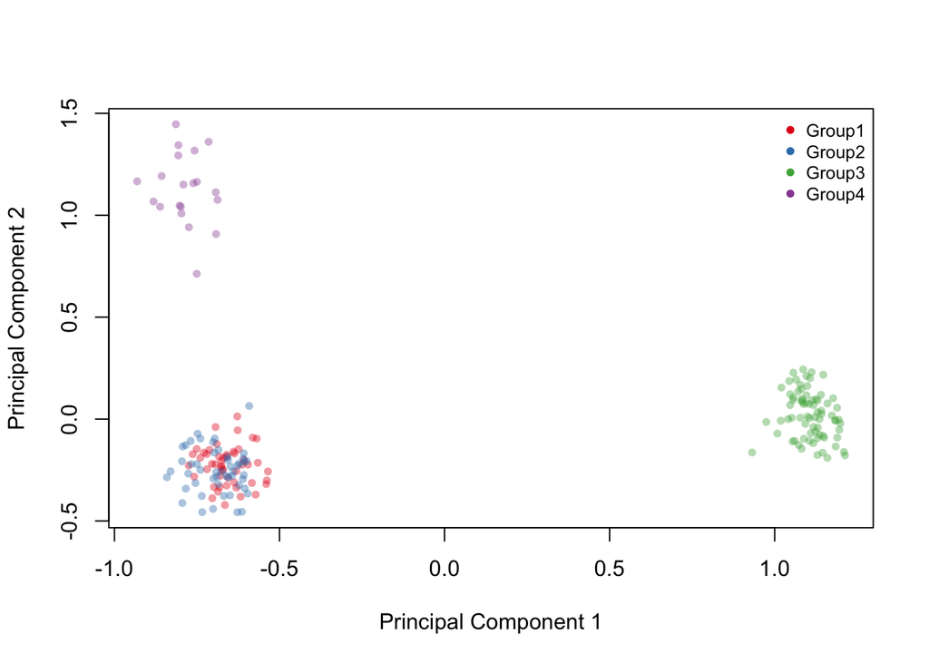

```r
#Define a new colour palette with enough colours for the nine different categories
pal <- brewer.pal(9,"Set1")

## Add an alpha value to a colour
add.alpha <- function(col, alpha=1){
  if(missing(col))
    stop("Please provide a vector of colours.")
  apply(sapply(col, col2rgb)/255, 2,
                     function(x)
                       rgb(x[1], x[2], x[3], alpha=alpha))
}

pal_alpha = add.alpha(pal,alpha=0.4)

#Define marker set as a vector
pchvec <- c(1:5)
plotMDS(y.keep,top=1000,gene.selection="common",cex=0.8,col=pal_alpha[as.factor(targets$Group)],pch=16)
legend('topright',legend=unique(levels(as.factor(targets$Group))),col=pal,cex=0.8,bty = "n",pch=16)
```

So hopefully you will see that (as in the example above) your data separates and clusters into the different categories. If this is not the case, that is the first warning sign that perhaps your data is not good enough to make a dependable classifier; perhaps you have large technical batch effects between samples….Remember your classifier is only as good as the data you train on. *In the above example I have purposely simulated two of the groups as having very similar expression profiles.*

# Train Building

First we want to decide is how many (and which) of those thousands of gene we wish to use in our random forest model. The most agnostic approach is to use all genes, but this is computationally heavy and includes a lot of bloat. Since we have already seen that the different samples separate well by PC1 and PC2 it is probably fair to use the top 1000 most variable genes as these should contain most,if not all, of the biology.

```r
#Transpose dataset so rows are different unique observations (i.e the samples) and columns are the classifier variables (i.e the genes)
datExpr <- t(FPKM)

#High variable lund
sd_counts <-apply(FPKM,1,sd)

#sort
sd_counts <- sort(sd_counts,decreasing=TRUE)

datExpr <- datExpr[,names(sd_counts)]

datExpr <- datExpr[,c(1:1000)]
```

Now we have our lovely dataset in a good and sensible form we can partition it into samples which we want to build and train our classifier with and part that we will then test the accuracy of our classifier on. Here we will take perhaps 80% of the dataset to train on and 20% to test on.

```r
nTest = ceiling(nrow(datExpr) * 0.2) #Take 80% of the rows randomly from the dataset for testing

set.seed(1) #Set a seed for reproducibility
ind = sample(nrow(datExpr),nTest,FALSE) #Sample a random set of indices comprising 20%

df.train <- datExpr[-ind,] #Take last 80% for training
df.test <- datExpr[ind,] #20% to test on

classtrain <- as.factor(targets[-ind,1])
classtest <- as.factor(targets[ind,1])
```

# Fine Tuning

Now before we create the classifier we need to decide on some hyperparameters for the random forest. None of the hyperparameters are vital but more of a fine tuning. There are two parameters one can set:

- The **number of decision trees** to use to classify. The more the better, however at a certain number of trees the classifier accuracy saturates and having more trees doesn’t reduce the error rate but only results in longer and unecessary computation time.
- Secondly, **mtry**, the number of different variables (genes) to try at each fork (decision) of the decision tree. This is by deafult the square root of the number of variables included and does a reasonable job.

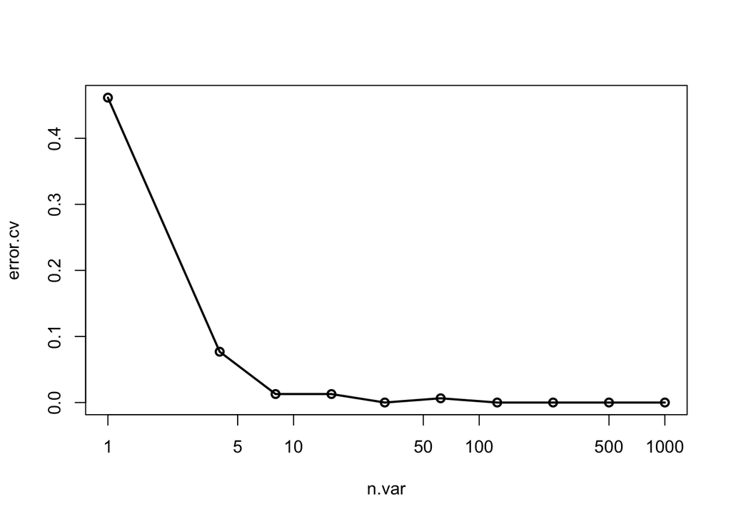

```r
#Now cross-validate RF to do feature selection and find mtry,ntree e.t.c
result <- rfcv(data.frame(df.train),classtrain, cv.fold=5)
with(result, plot(n.var, error.cv, log="x", type="o", lwd=2))
```

What the above illustrates is how the error rate of the classifier changes as a function of the number of predictor variables (genes) included in the classifier. What one ideally wants to see is a roughly exponentially curve where the error rate is decreasing as a function of predictors but flattens out at some point such that including more genes doesn’t really improve accuracy. At that point the accuracy of the classifier cannot really be improved by adding more genes. So this is the minimum number of genes you probably want to use to classify with, in the case perhaps twenty.

We can if we do not wish to use the default value, use the tuneRF function to cross-validate to find out what the best value for *mtry* is:

```r
#Now tuneRF to find mtry and ntree
tuneRF(df.train,classtrain,mtryStart=50,stepFactor=0.5)
```

```
## mtry = 50  OOB error = 1.92%
## Searching left ...
## mtry = 100   OOB error = 0.64%
## 0.6666667 0.05
## mtry = 200   OOB error = 0.64%
## 0 0.05
## Searching right ...
## mtry = 25    OOB error = 5.77%
## -8 0.05
```

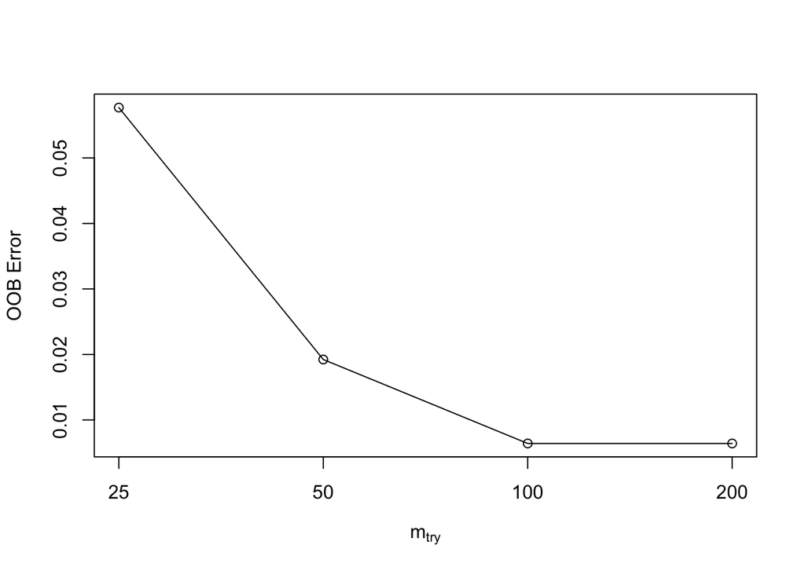

```
##         mtry    OOBError
## 25.OOB    25 0.057692308
## 50.OOB    50 0.019230769
## 100.OOB  100 0.006410256
## 200.OOB  200 0.006410256
```

# How to train your classifier

Everything is in place, data prepared, tuning done, let’s go….

```r
#Now train the random forest
set.seed(1) #Set the seed in order to gain reproducibility
#Random forest only accepts a data.frame, not a matrix, hence conver
RF = randomForest(classtrain~., data=df.train,importance=T,mtry=100,proximity=TRUE)
RF
```

```
##
## Call:
##  randomForest(formula = classtrain ~ ., data = df.train, importance = T,      mtry = 100, proximity = TRUE)
##                Type of random forest: classification
##                      Number of trees: 500
## No. of variables tried at each split: 100
##
##         OOB estimate of  error rate: 0.64%
## Confusion matrix:
##        Group1 Group2 Group3 Group4 class.error
## Group1     41      0      0      0  0.00000000
## Group2      1     38      0      0  0.02564103
## Group3      0      0     59      0  0.00000000
## Group4      0      0      0     17  0.00000000
```

# Time to test

So having constructed the classifier from 80% of our data we can now test it on the remaining 20%. This is important since of course the classifier will have a good accuracy on those samples it was trained on, but we want to see how well it performs on others:

```r
RFpred <- predict(RF,data.frame(df.test))
RFprob <-predict(RF,data.frame(df.test),type="prob")
```

Lets have a little peek that the classifier is doing something sensible, we can make a quick MDS plot using simply the genes used in the classifier and see that all the four classes separate well.

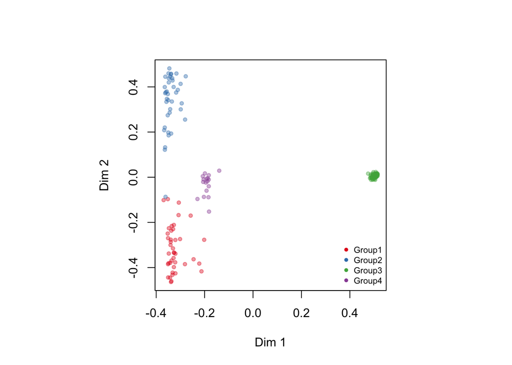

```r
#View MDS
MDSplot(RF, classtrain,palette=pal_alpha)
legend("bottomright",legend=unique(levels(classtrain)),col=pal,pch=16,cex=0.7,bty = "n")
```

```r
out = data.frame(Predicted= RFpred, Truth = classtest)
#First make matrix
conf = table(out)
print(conf)
```

```
##          Truth
## Predicted Group1 Group2 Group3 Group4
##    Group1      8      0      0      0
##    Group2      1     11      0      0
##    Group3      0      0     16      0
##    Group4      0      0      0      3
```

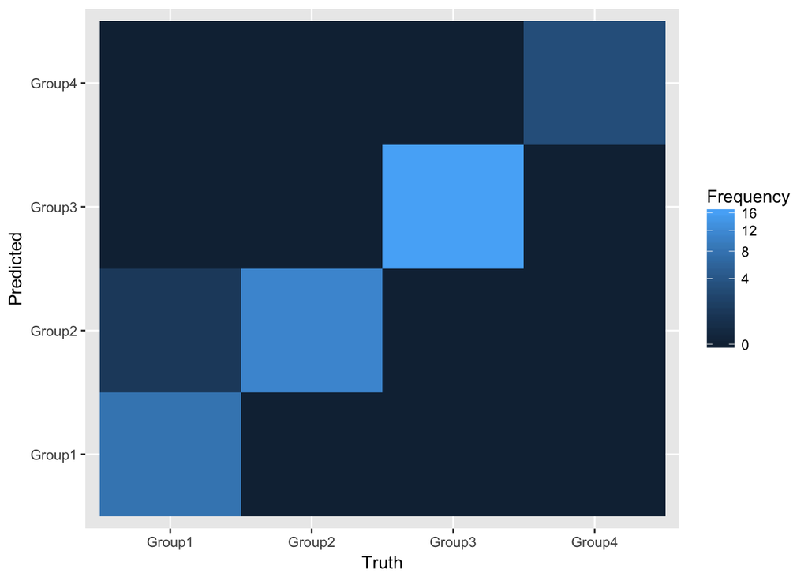

```r
#Rejig matrix to table then to dataframe
confusion = as.data.frame(conf)
gg <- ggplot(confusion,aes(x=Truth,y=Predicted,fill=Freq))
gg + geom_tile() + labs(fill="Frequency") + scale_fill_gradient(trans = "sqrt")
```

# Digging for gems

One last piece of investigation you can do is to see which of the variables (genes) are the most important for distinguishing the different classes as this may help identify potential biological markers and help us understand the biology of the different sub-classes better. One can measure the importance of a variable by many different metrics but the Gini coefficient is one of the most popular:

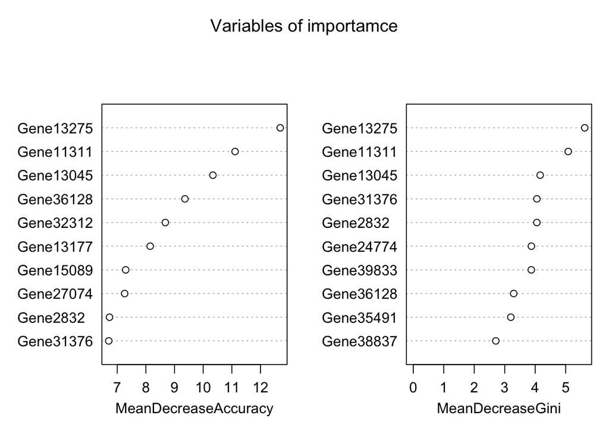

```r
#Extract variable importance
var.imp = data.frame(importance(RF))
#Looking into the importance of different variables
varImpPlot(RF,main="Variables of importamce",n.var=10)
```

As a sanity check you may also may want to take the 10-20 most important genes, subset your original FPKM and check whether by doing unsupervised clustering such as hierarchical clustering we can obtain clustering by group:

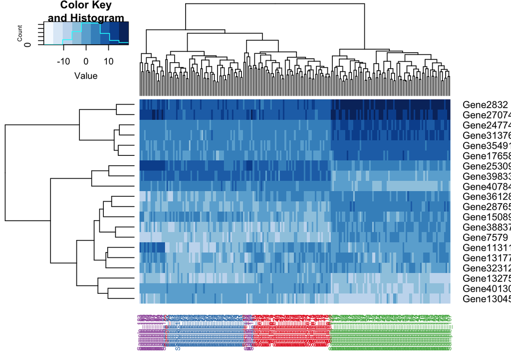

```r
#Extract top genes
topgenes = rank(-var.imp$MeanDecreaseGini,ties.method="first") <= 20
topdata = datExpr[,topgenes] #subset
yx <- as.matrix(t(topdata)) #Transpose back and matrixify
heatmap.2(yx,colCol=pal[as.factor(targets$Group)],trace = "none",col =brewer.pal(9,"Blues"))
```

As you can see the most important genes lead to a decent clustering even with a simple hierarchical clustering, so our random forest classifier is doing a good job of picking out sensible genes.

# Conclusions

So now we have a decent classifier and we have assessed its accuracy and tried to extract even some of the biology.

*Where to go from here?*

- So now you could replace the classifier in the AllSorts with your own bespoke classifier and use all its functionality!
- You could choose just the top most important genes and retrain the classifier (with the same method as above) to classify just using the subset of genes for a quick and less biased test.
- Try to combine several datasets into one (Cautionary tale: Watch out for the dreaded batch effects)